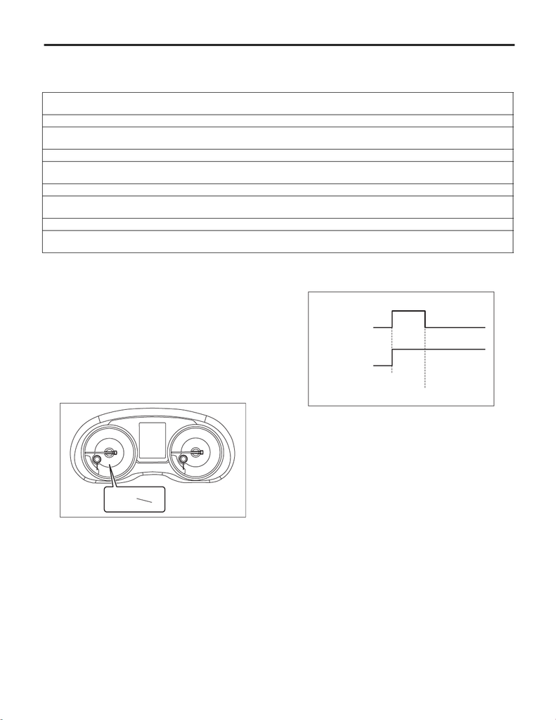

Malfunction Indicator Light

ENGINE (DIAGNOSTICS)

15.Malfunction Indicator Light

A: PROCEDURE

B: ACTIVATION OF MALFUNCTION

INDICATOR LIGHT

1) When the ignition switch is turned to ON (engine

OFF), the malfunction indicator light (A) in the com-

bination meter illuminates.

NOTE:

If the malfunction indicator light does not illuminate,

perform diagnostics of the malfunction indicator

light circuit or the combination meter circuit. <Ref.

to EN(STI)(diag)-63, MALFUNCTION INDICATOR

LIGHT DOES NOT COME ON, Malfunction Indica-

tor Light.>

2) After starting the engine, the malfunction indica-

tor light goes out. If it does not go off, any of the en-

gine and emission control system has malfunction.

1. Activation of malfunction indicator light <Ref. to EN(STI)(diag)-61, ACTIVATION OF MALFUNCTION INDICATOR LIGHT, Mal-

function Indicator Light.>

↓

2. Malfunction indicator light does not come on <Ref. to EN(STI)(diag)-63, MALFUNCTION INDICATOR LIGHT DOES NOT

COME ON, Malfunction Indicator Light.>

↓

3. Malfunction indicator light does not go off <Ref. to EN(STI)(diag)-63, MALFUNCTION INDICATOR LIGHT DOES NOT GO OFF,

Malfunction Indicator Light.>

↓

4. Malfunction indicator light does not blink <Ref. to EN(STI)(diag)-64, MALFUNCTION INDICATOR LIGHT DOES NOT BLINK,

Malfunction Indicator Light.>

↓

5. Malfunction indicator light remains blinking <Ref. to EN(STI)(diag)-66, MALFUNCTION INDICATOR LIGHT REMAINS BLINK-

ING, Malfunction Indicator Light.>

CHECK

ENGINE

(A)

CHECK

ENGINE

EN-10841

(1) No DTC

(2) Trouble occurs

(3) ON

(4) OFF

(5) Ignition switch ON

(6) Engine start

EN-01679

(1)

(2)

(5)

(6)

(3)

(4)

(3)

(4)

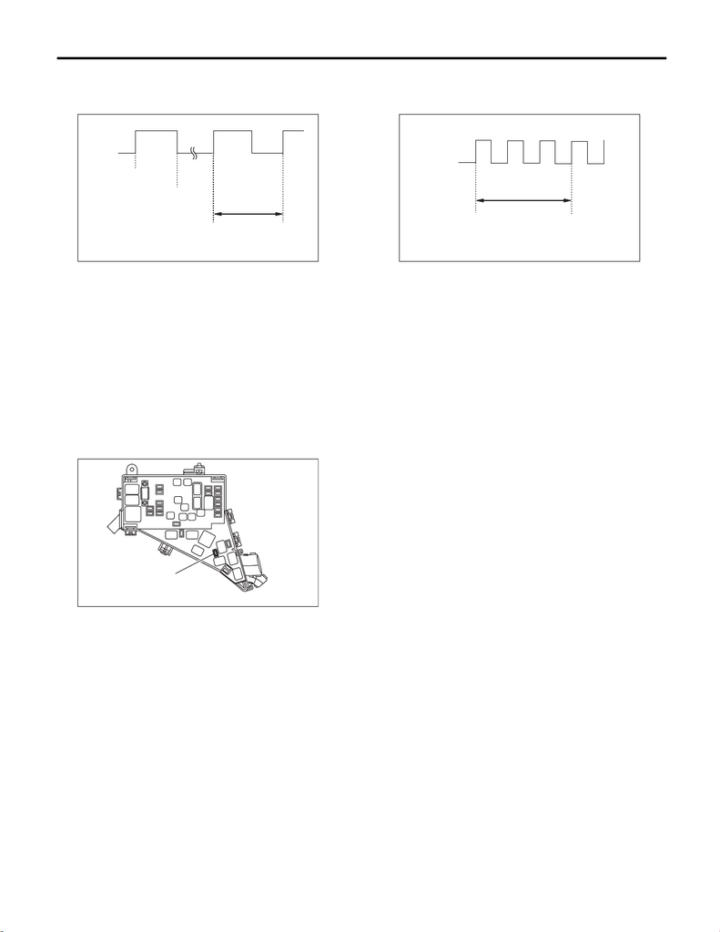

Malfunction Indicator Light

ENGINE (DIAGNOSTICS)

3) If the diagnostic system detects a misfire which

could damage the catalyst, the malfunction indica-

tor light will blink at a cycle of 1 Hz.

4) Turn the ignition switch to OFF and install the

delivery mode fuse (A).

CAUTION:

Do not use any fuses that are installed on the

vehicle.

(1) When the ignition switch is turned to ON

(engine OFF), the malfunction indicator light il-

luminates.

(2) After the engine starts, malfunction indicator

sis)

(3) Malfunction indicator light blinks at a cycle of

3 Hz after diagnosis if there is no trouble. Mal-

function indicator light illuminates if faulty.

(1) ON

(2) OFF

(3) Ignition switch ON

(4) Engine start

(5) Misfire start

(6) 1 second

(2)

(1)

(3)

(4)

(5)

(6)

EN-01680

EN-10881

(A)

(1) ON

(2) OFF

(3) Ignition switch ON

(4) 1 second

EN-01681

(2)

(1)

(4)

(3)

[figure not shown]

Malfunction Indicator Light

ENGINE (DIAGNOSTICS)

C: MALFUNCTION INDICATOR LIGHT DOES NOT COME ON

TROUBLE SYMPTOM:

When the ignition switch is turned to ON (engine OFF), malfunction indicator light does not illuminate.

NOTE:

Refer to IDI section for diagnostic procedure. <Ref. to IDI(diag)-2, Basic Diagnostic Procedure.>

D: MALFUNCTION INDICATOR LIGHT DOES NOT GO OFF

TROUBLE SYMPTOM:

Although malfunction indicator light comes on when the engine runs, DTC is not shown on the Subaru Select

Monitor or general scan tool display.

Step Check Yes No

1 CHECK DTC. Is DTC of engine or LAN sys-

tem displayed? <Ref. to

EN(STI)(diag)-42, OPERA-

TION, Read Diagnostic Trouble

Code (DTC).>

Check the appro-

priate DTC using

the “List of Diag-

nostic Trouble

Code (DTC)”.

<Ref. to

EN(STI)(diag)-86,

List of Diagnostic

Trouble Code

(DTC).> <Ref. to

LAN(diag)-70, List

of Diagnostic Trou-

ble Code (DTC).>

Check the combi-

nation meter sys-

tem. <Ref. to

IDI(diag)-2, Basic

Diagnostic Proce-

dure.>

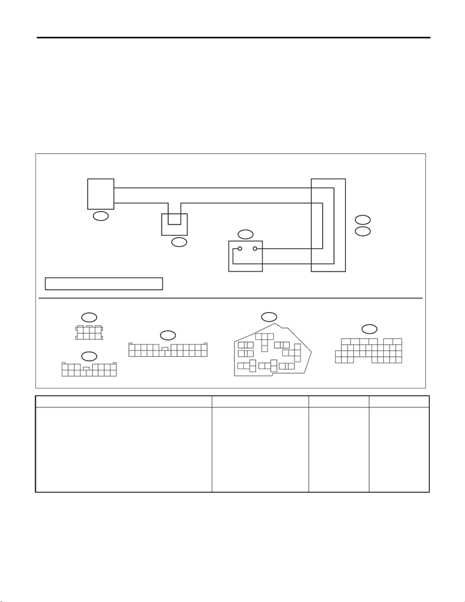

Malfunction Indicator Light

ENGINE (DIAGNOSTICS)

E: MALFUNCTION INDICATOR LIGHT DOES NOT BLINK

DIAGNOSIS:

• The malfunction indicator light circuit is open or shorted.

• Delivery mode fuse circuit is open.

TROUBLE SYMPTOM:

Malfunction indicator light does not blink during Inspection Mode.

WIRING DIAGRAM:

• Engine Electrical System ENGINE TYPE EJ (WITHOUT PUSH BUTTON START) <Ref. to WI-198, EN-

GINE TYPE EJ (WITHOUT PUSH BUTTON START), WIRING DIAGRAM, Engine Electrical System.>

• Engine Electrical System ENGINE TYPE EJ (WITH PUSH BUTTON START) <Ref. to WI-218, ENGINE

TYPE EJ (WITH PUSH BUTTON START), WIRING DIAGRAM, Engine Electrical System.>

Step Check Yes No

1 CHECK STATUS OF MALFUNCTION INDI-

CATOR LIGHT.

1) Turn the ignition switch to OFF.

2) Make sure that the delivery mode fuse is

removed.

3) Turn the ignition switch to ON. (engine OFF)

Does the malfunction indicator

light illuminate?

Go to step 2. Repair the mal-

function indicator

light circuit. <Ref.

to EN(STI)(diag)-

63, MALFUNC-

TION INDICATOR

LIGHT DOES NOT

COME ON, Mal-

function Indicator

Light.>

B136

4

34

B122

J/C

B20

C10

C2

B6

9

8

F27

89

10 11 12 13 14 15 16

C: B360

3412 89

10 11

567

B: F109

EN-10850

24

23

25

12 13 14

15

16

26

2221

20

19

1817

10 11

2

4

5

13

7698

F27

B122

34

56

12

78

2524

30

987

17 18 19 20

28

21 22 23

29

3231

1234

56

2726

33 34 35

B136

B: F109

C: B360

ECM

THROUGH JOINT

CONNECTOR

: TERMINAL No. OPTIONAL ARRANGEMENT

DELIVERY MODE FUSE

[figure not shown]

Malfunction Indicator Light

ENGINE (DIAGNOSTICS)

2 CHECK HARNESS BETWEEN ECM AND DE-

LIVERY MODE FUSE.

1) Turn the ignition switch to OFF.

2) Disconnect the connector from ECM.

3) Install the delivery mode fuse.

4) Measure the resistance of harness between

ECM connectors.

Connector & terminal

(B136) No. 34 — (B136) No. 4:

Is the resistance less than 1 Ω? Go to step 3. Repair the harness

and connector.

NOTE:

In this case, repair

the following item:

• Open circuit in

harness between

ECM connector

• Poor contact of

each connector

between ECM con-

nector

3 CHECK FOR POOR CONTACT.

Check for poor contact of ECM connector.

Is there poor contact of ECM

connector?

Repair the poor

contact of ECM

connector.

Replace the ECM.

<Ref. to FU(STI)-

56, Engine Control

Module (ECM).>

Step Check Yes No

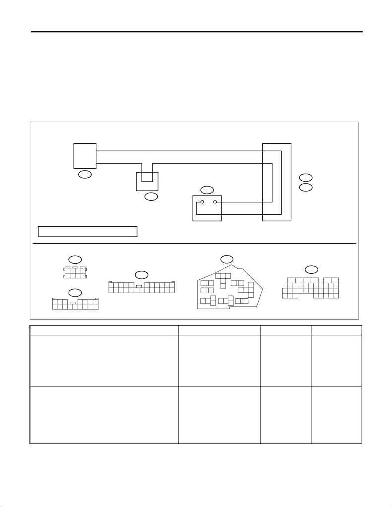

Malfunction Indicator Light

ENGINE (DIAGNOSTICS)

F: MALFUNCTION INDICATOR LIGHT REMAINS BLINKING

DIAGNOSIS:

Delivery mode fuse circuit is shorted to ground.

TROUBLE SYMPTOM:

Malfunction indicator light blinks when delivery mode fuse is not installed.

WIRING DIAGRAM:

• Engine Electrical System ENGINE TYPE EJ (WITHOUT PUSH BUTTON START) <Ref. to WI-198, EN-

GINE TYPE EJ (WITHOUT PUSH BUTTON START), WIRING DIAGRAM, Engine Electrical System.>

• Engine Electrical System ENGINE TYPE EJ (WITH PUSH BUTTON START) <Ref. to WI-218, ENGINE

TYPE EJ (WITH PUSH BUTTON START), WIRING DIAGRAM, Engine Electrical System.>

Step Check Yes No

1 CHECK DELIVERY MODE FUSE.

1) Make sure that the delivery mode fuse is

removed.

2) Turn the ignition switch to ON.

Does the malfunction indicator

light blink?

Go to step 2. System is normal.

NOTE:

Malfunction indica-

tor light blinks at a

cycle of 3 Hz when

delivery mode fuse

is installed.

2 CHECK HARNESS BETWEEN ECM AND DE-

LIVERY MODE FUSE.

1) Turn the ignition switch to OFF.

2) Disconnect the connector from ECM.

3) Measure the resistance between ECM con-

nector and chassis ground.

Connector & terminal

(B136) No. 34 — Chassis ground:

Is the resistance 1 MΩ or

more?

Replace the ECM.

<Ref. to FU(STI)-

56, Engine Control

Module (ECM).>

Repair the short

circuit to ground in

harness between

ECM connector

and delivery mode

fuse.

B136

4

34

B122

J/C

B20

C10

C2

B6

9

8

F27

89

10 11 12 13 14 15 16

C: B360

3412 89

10 11

567

B: F109

EN-10850

24

23

25

12 13 14

15

16

26

2221

20

19

1817

10 11

2

4

5

13

7698

F27

B122

34

56

12

78

2524

30

987

17 18 19 20

28

21 22 23

29

3231

1234

56

2726

33 34 35

B136

B: F109

C: B360

ECM

THROUGH JOINT

CONNECTOR

: TERMINAL No. OPTIONAL ARRANGEMENT

DELIVERY MODE FUSE